# Methods 4 – Portfolio Assignment 2

- *Type:* Group assignment
- *Due:* 3 April 2022, 23:59

Hello CogSci’s :)

In this portfolio, you are asked to do four tasks:

- Make a DAG for something

- Simulate data that fits the DAG

- Use linear models to confirm that the DAG fits the data

- Mess it up.

Each of the four tasks have some sub-steps.  
Report briefly what you find, for example in a markdown document, for example called report.md so that the poor TA can easily get an overview before looking in your code :)

Then you can also make a (brief!) explanation of the phenomenon you are DAGGIN, simulating and modelling.

Looking forward!

## Task 1: The DAG

- **Come up with an** incredibly interesting and scientifically important made-up **example** for a phenomenon to investigate. Decide on two variables (an outcome and a predictor) that you would like to investigate the relation between. If in doubt, you **can be inspired by Peter’s amazing example** on the next page.

*In our example, we wish to investigate the effect of the predictor corona fear (CF) on* *the outcome variable Infected (a binary variable taking either the value 0 or 1)*

*Since Denmark reported it’s first case of COVID-19 contraction on the 27th February 2020 (STPS, 2020),* *COVID-19 and its development has been subject to extensive coverage in Danish media.* *News media has a critical role in times of epidemic crises since* *exposure to as well as consumption of information in times of pandemics* *may alter people’s perception and provoke behavioural changes that* *might ultimately impact the evolution and further spread of the virus (Gozzi et al., 2020).*

*We therefore expect that corona fear is a sensible predictor of whether one* *gets infected or not, assuming that the degree to which one fears* *COVID determines the precautions and actions one take to avoid getting infected.*

*Predictor: corona fear (continuous variable)* *Outcome variable: infection (0/1)* *Sanitizing: continuous variable* *FM variable: do you wear face mask according to the national guidelines? (for the sake of simplicity, we assume that this is a binary variable taking either the value 0 or 1, meaning that you either always where a face mark when the guidelines advises you to do that (1) and never wear it in situations were the national guidelines advises it. We do acknowledge that is a false dichotomy)* *Germ level: the level of vira germs in your body. We have no biological evidence for a variable of this type, but for the sake of simplicity we assumes that the level of germs present in your body can be describes as a normally distributed continuous variable* *OCD variable: A categorical variable that takes a value between 1 and 5, which reflects the severity of the OCD condition (Obsessive Compulsive Disorder). 1 being no OCD symptoms at all and 5 being very severe OCD*

- **Make a DAG** for the phenomenon. Make it medium complicated: that means, make sure there are some different kinds of relations (see next step). Change it if you don’t get anything interesting for the next steps.  
**Draw it** somehow (on paper, in R, laser engraved in diamond).  
**Code it** in dagitty (this is a nice tool: http://dagitty.net/dags.html )

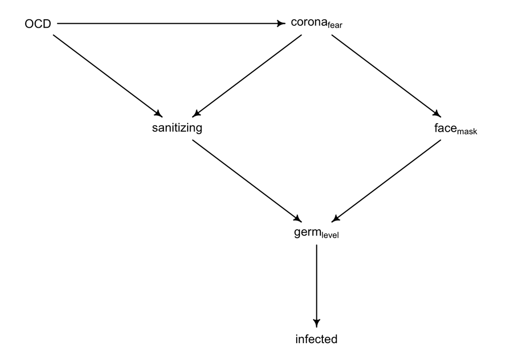

```r
# Twisted DAG corona

dag_corona <- dagitty( "dag {
    corona_fear -> sanitizing
    sanitizing-> germ_level
    OCD -> sanitizing
    OCD -> corona_fear
    face_mask -> germ_level
    corona_fear -> face_mask
    germ_level -> infected
}")

# Plotting the DAG
coordinates(dag_corona) <- list(
  x=c(corona_fear =-1, OCD = -3, face_mask =0, sanitizing =-2, germ_level=-1, infected= -1) ,
  y=c(corona_fear =-1, OCD = -1, face_mask =0, sanitizing = 0, germ_level=1, infected=2) )

drawdag(dag_corona)
```

- Find **elemental forms of variable relations** in the DAG (i.e., forks, pipes, colliders, and their descendants).

Pipe

(FM -> GERM LEVEL -> INFECTED)

(Cf –> FM –> GERM)

(CF -> S -> GERM)

(S –> GERM –> INFECTED)

(OCD –> CF –> FM)

(OCD –> S –> GERM LEVEL)

Fork

(S <- CF -> FM)

(CF <- OCD -> S)

Collider

(S -> GERM LEVEL <- FM)

(CF-> S <- OCD)

Descendant

(OCD –> CF –> FM, CF –> S )

*We expect OCD to affect your corona fear in such way that a higher level of OCD increase the level of corona fear.*

*A typical symptom of OCD is an abnormal fear of germs, which results in highly frequent use of sanitizer. Thus, we assume that the amount of sanitizing will increase with the level of OCD*.

*We expect the variable FM to depend on your corona fear, as we assume that a person who is really scared of COVID would be much more* *likely to strictly follow the national guidelines, whereas a person who didn’t fear corona at all would reversely be much less likely to* *wear a face mask although the national guidelines advises one to do it*

*The same goes for the relation between corona fear and sanitizing. We expect a person with a high corona fear to have a much higher* *daily frequency of sanitizing than a person with no corona fear at all*.

*We would expect germ level to depend on whether you wear face mask when advised to or not, as* *the face mask (at least partly) prevents germs from entering your mouth and nose*.

*The same goes for the relation between germ level and sanitizing, as* *sanitizing works by killing most germs, preventing them from entering your body*

*Lastly, we expect the level of germs to determine whether you are infected or not. With a low level of germs,* *one would expect your immune system would be strong enough to fight the few germs that have entered your body.* *However, if the level of germs in your body is extremely high, it might exceed the capacity of your immune system* *to fight back, resulting in you getting infected.*

- Find out **what variables to include (and not include)** in a multiple linear regression to avoid ‘back door’ (AKA non-causal) paths. Do this first with your eyes and your mind. Then you can use dagitty’s function `adjustmentSets()`.

```r
# Shutting the backdoor - analyzing the graph to block the backdoor
adjustmentSets(dag_corona,exposure="corona_fear", outcome="infected")
```

```
## { OCD }
```

OCD is a backdoor that we should control for (i.e., include in a our model) in order to find the full causal effect of corona fear on infected.

- Find out which **conditional independencies** the DAG implies. First with the mind, then with daggity’s function `impliedConditionalIndependencies()`.

```r
# Deriving our DAG’s conditional independencies
impliedConditionalIndependencies(dag_corona)
```

```
## OCD _||_ fc_m | crn_
## OCD _||_ grm_ | fc_m, sntz
## OCD _||_ grm_ | crn_, sntz
## OCD _||_ infc | grm_
## OCD _||_ infc | fc_m, sntz
## OCD _||_ infc | crn_, sntz
## crn_ _||_ grm_ | fc_m, sntz
## crn_ _||_ infc | grm_
## crn_ _||_ infc | fc_m, sntz
## fc_m _||_ infc | grm_
## fc_m _||_ sntz | crn_
## infc _||_ sntz | grm_
```

```
OCD _||_ fc_m | crn_
OCD _||_ grm_ | fc_m, sntz
OCD _||_ grm_ | crn_, sntz
OCD _||_ infc | grm_
OCD _||_ infc | fc_m, sntz
OCD _||_ infc | crn_, sntz
crn_ _||_ grm_ | fc_m, sntz
crn_ _||_ infc | grm_
crn_ _||_ infc | fc_m, sntz
fc_m _||_ infc | grm_
fc_m _||_ sntz | crn_
infc _||_ sntz | grm_
```

The above shows the testable implications of our DAG, which we will go through in task 3 to test if any of them can be falsified - i.e. to know if the DAG is compatible with the data. If any of the conditional independencies are not fulfilled, we can falsify our DAG.

- Find the full list of **Markov equivalent** DAGS. Use daggity’s function `equivalentGraphs()`.

The equivalentGraphs() function outputs a set of DAGs with the same conditional independencies is known as a Markov equivalence set.

The list outputted allow show us 8 DAGS that would have the exact same conditional independencies as our dag_corona has.

```r
equivalentDAGs(dag_corona)
```

```
## [[1]]
## dag {
## OCD [pos="-3.000,-1.000"]
## corona_fear [pos="-1.000,-1.000"]
## face_mask [pos="0.000,0.000"]
## germ_level [pos="-1.000,1.000"]
## infected [pos="-1.000,2.000"]
## sanitizing [pos="-2.000,0.000"]
## OCD -> corona_fear
## OCD -> sanitizing
## corona_fear -> face_mask
## corona_fear -> sanitizing
## face_mask -> germ_level
## germ_level -> infected
## sanitizing -> germ_level
## }
##
## [[2]]
## dag {
## OCD [pos="-3.000,-1.000"]
## corona_fear [pos="-1.000,-1.000"]
## face_mask [pos="0.000,0.000"]
## germ_level [pos="-1.000,1.000"]
## infected [pos="-1.000,2.000"]
## sanitizing [pos="-2.000,0.000"]
## OCD -> corona_fear
## OCD -> sanitizing
## corona_fear -> face_mask
## face_mask -> germ_level
## germ_level -> infected
## sanitizing -> corona_fear
## sanitizing -> germ_level
## }
##
## [[3]]
## dag {
## OCD [pos="-3.000,-1.000"]
## corona_fear [pos="-1.000,-1.000"]
## face_mask [pos="0.000,0.000"]
## germ_level [pos="-1.000,1.000"]
```

[output cut: 80 more lines]

```
## dag {
## OCD [pos="-3.000,-1.000"]
## corona_fear [pos="-1.000,-1.000"]
## face_mask [pos="0.000,0.000"]
## germ_level [pos="-1.000,1.000"]
## infected [pos="-1.000,2.000"]
## sanitizing [pos="-2.000,0.000"]
## corona_fear -> OCD
## corona_fear -> sanitizing
## face_mask -> corona_fear
## face_mask -> germ_level
## germ_level -> infected
## sanitizing -> OCD
## sanitizing -> germ_level
## }
```

## Task 2: The data

- **Simulate some data that fits the DAG.** There are many ways to do this. A simple way is just to sample one variable from a normal distribution which has another variable as mean. McElreath does this in the book a few times, and you can use this as inspiration.

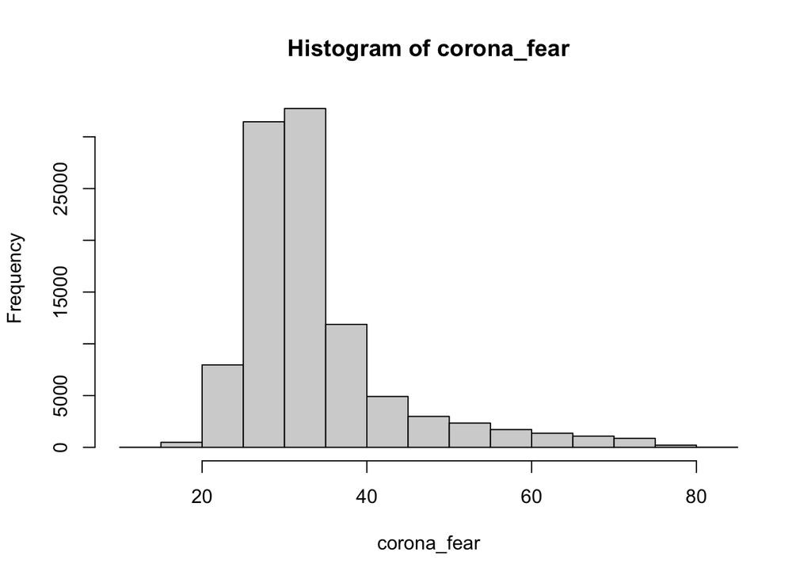

```r
set.seed(1)
N = 100000

# Simulating variables:

# OCD
OCD <- sample(1:5, size=N, replace=TRUE, prob=c(.8, .10, .05, .03, .02))

# Corona fear (assuming that it is normally distributed and dependent on OCD)
corona_fear <-rnorm(N, mean=20+(10*OCD), sd=4)
hist(corona_fear)
```

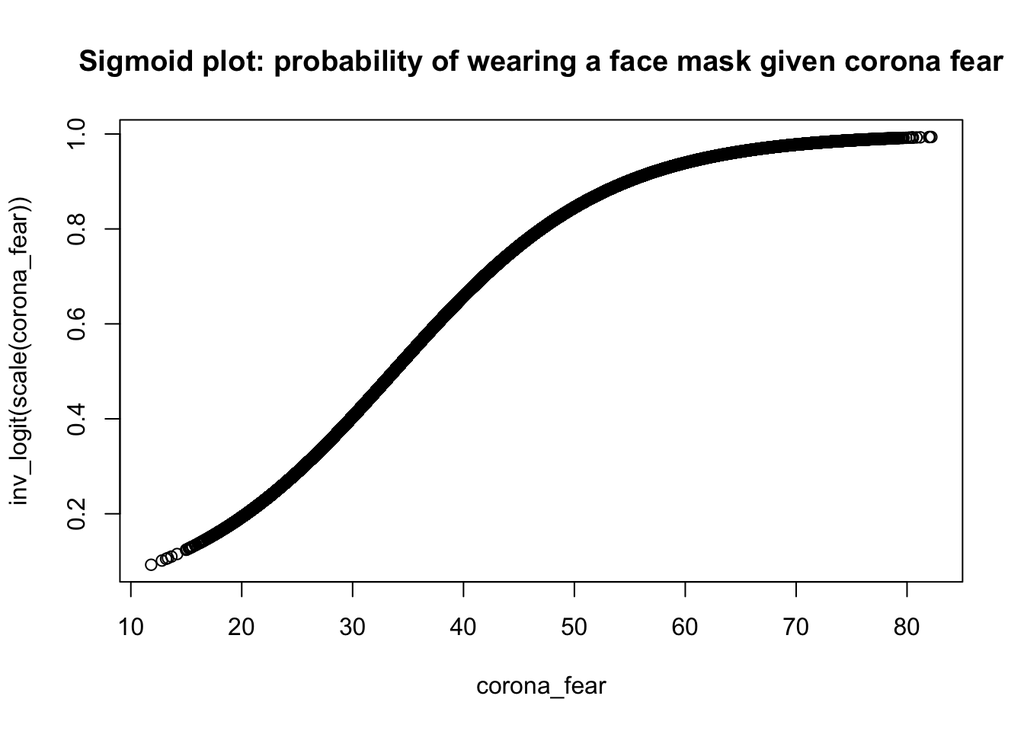

```r
# Face mask (is dependent on corona_fear)
face_mask <- rbinom(N, size =1, prob=inv_logit(scale(corona_fear*2)))
plot(corona_fear, inv_logit(scale(corona_fear)), main= "Sigmoid plot: probability of wearing a face mask given corona fear")
```

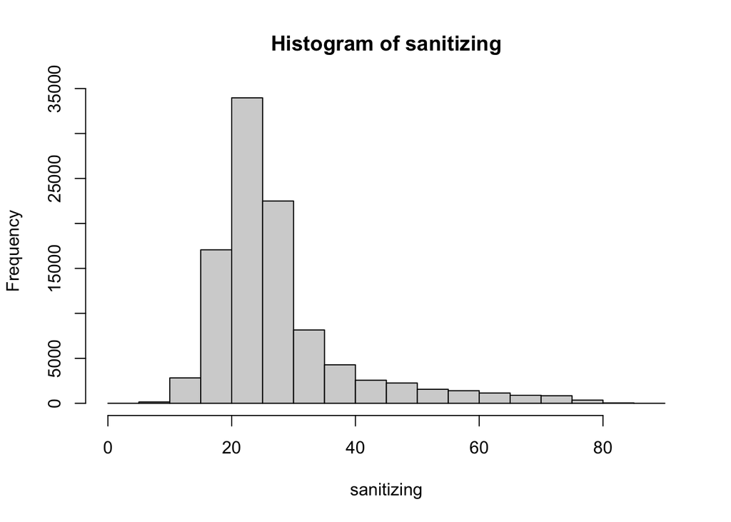

```r
# Sanitizing (is dependent on corona_fear and OCD)
sanitizing <-  rnorm(N, mean= (corona_fear-9)+(OCD*2), sd=2)
hist(sanitizing)
```

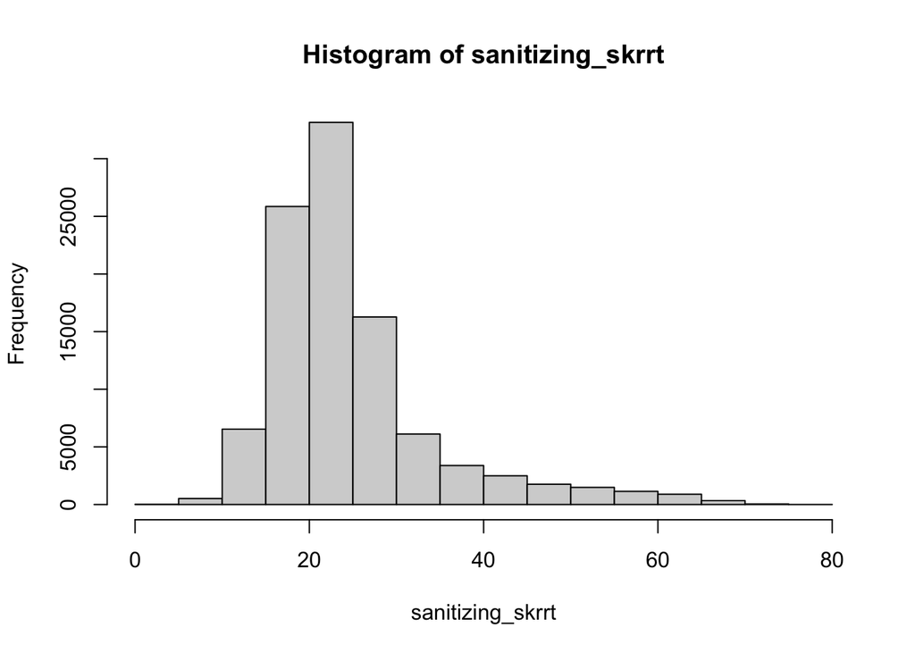

```r
sanitizing_skrrt <-  rnorm(N, mean= (corona_fear-9), sd=2)
hist(sanitizing_skrrt)
```

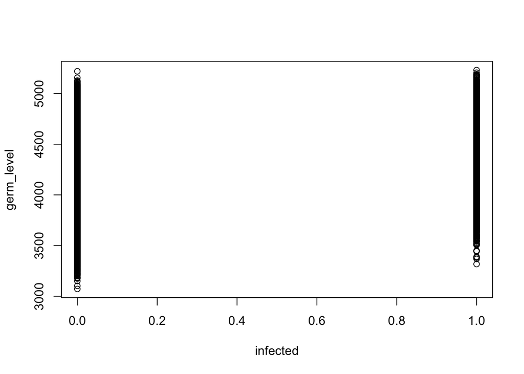

```r
# Germ level (is dependent on both sanitizing & whether you wear face mask or not)
germ_level <-  rnorm(N, mean= 5000 - ((sanitizing*10)*(1+face_mask)), sd=100)

# Probability of being infected (depends on your germ level)
infected <-  rbinom(N, size= 1, prob= inv_logit(scale(germ_level)))
#infected <- rnorm(N, mean=-0.8*germ_level+4200, sd = 2)
plot(infected,germ_level)
```

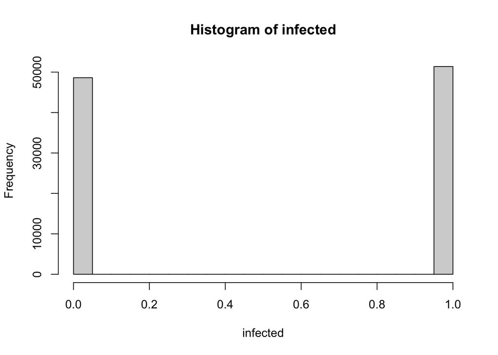

```r
hist(infected)
```

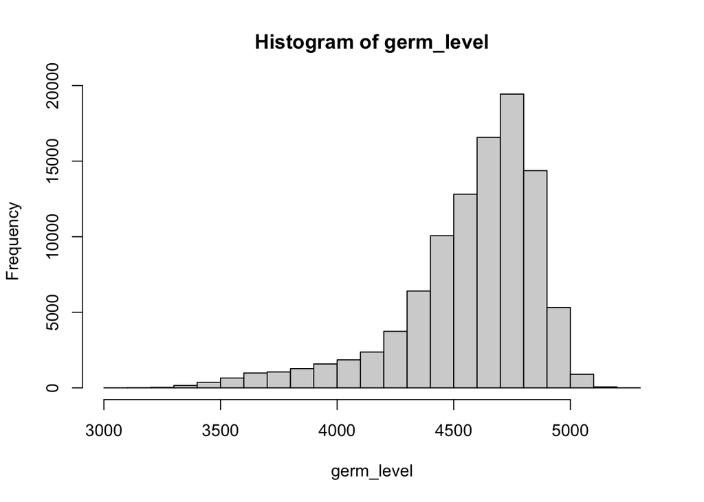

```r
hist(germ_level)
```

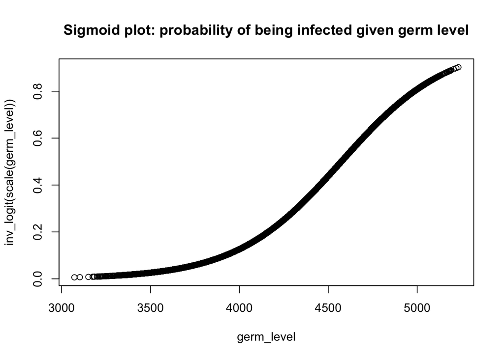

```r
plot(germ_level, inv_logit(scale(germ_level)), main= "Sigmoid plot: probability of being infected given germ level")
```

```r
# creating df
df <- tibble(germ_level, sanitizing, infected, face_mask, corona_fear, OCD)
```

*Standardizing variables* Standardizing variables: OBS CHRIS: SHOULD WE STANDARDIZE A DICHOTOMOUS VARIABLE, FM AND OCD!!!!!!

```r
df <- df %>%
  mutate(germ_std=scale(germ_level),
         sanitizing_std= scale(sanitizing),
         infected_std=scale(infected),
         face_mask_std=scale(face_mask),
         corona_fear_std= scale(corona_fear),
         #OCD_std= scale(OCD)
         )
```

## Task 3: Statistics

- Run **multiple linear regression**s to **test the conditional independencies** **implied by your DAG**. Make sure to avoid backdoor paths. See that the linear model shows the conditional independencies implied by your DAG, implying that the data and the DAG are compatible (if the linear model doesn’t show the conditional independencies implied by the DAG, the data and the DAG doesn’t fit).

### Testing the conditional independencies

Model 1: crn_ *||* grm_ | fc_m, sntz. Testing whether the causal coefficient germ_level is insignificant when stratifying by face_mask and sanitizing.

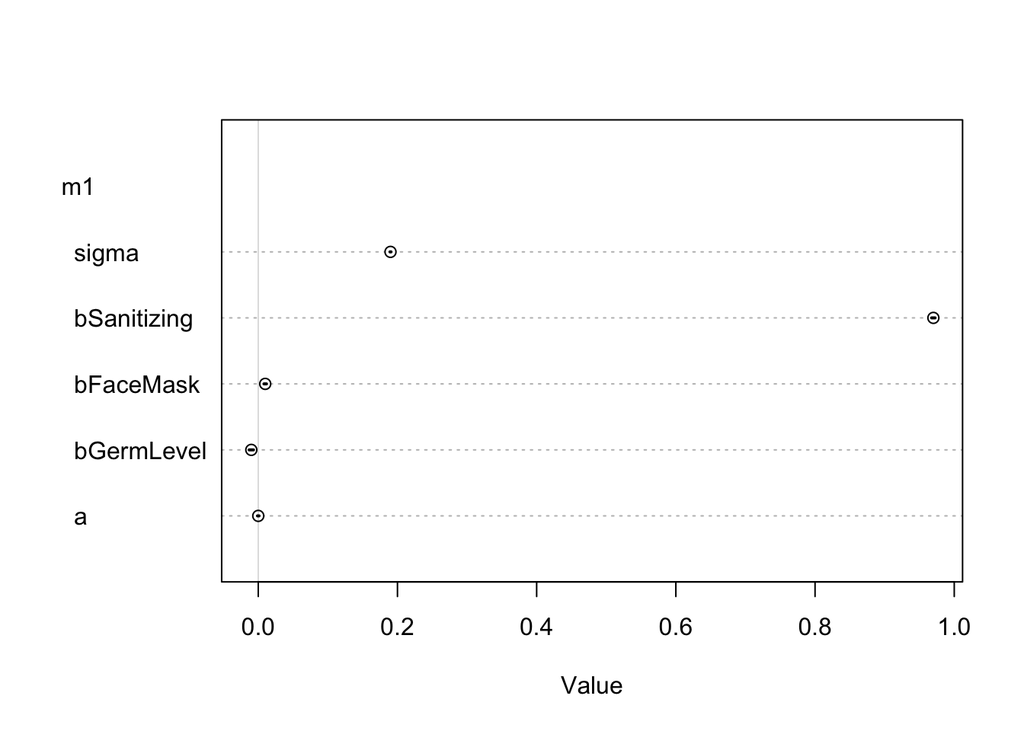

```r
m1<- quap(
    alist(
        corona_fear_std ~ dnorm( mu , sigma ) ,
        mu <- a  + bGermLevel*germ_std + bFaceMask*face_mask_std + bSanitizing*sanitizing_std,
        a ~ dnorm( 0 , 0.2 ) ,
        bGermLevel~ dnorm( 0 , 1 ),
        bFaceMask~ dnorm( 0 , 1 ) ,
        bSanitizing ~ dnorm( 0 , 1 ),
        sigma ~ dexp( 1 )
    ) , data = df )

plot(coeftab(m1),by.model=TRUE )
```

As seen in the above plot, corona fear and germ level becomes independent (i.e., the model with almost no uncertainty estimates the coefficient bGermLevel to be very close to zero ) when stratifying by face_mask and sanitizing.

Model 2: crn_ *||* infc | grm_ Testing whether the causal coefficient infc (being infected or not) is insignificant when stratifying by germ_level.

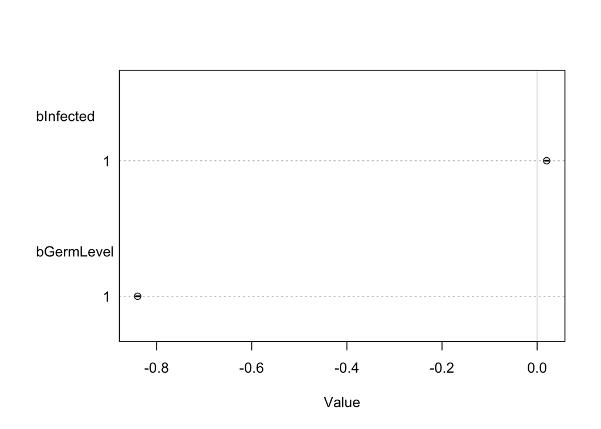

```r
m2<- quap(
    alist(
        corona_fear_std ~ dnorm( mu , sigma ) ,
        mu <- a + bInfected*infected_std  + bGermLevel*germ_std,
        a ~ dnorm( 0 , 0.2 ) ,
        bInfected ~ dnorm( 0 , 1 ) ,
        bGermLevel~ dnorm( 0 , 1 ),
        sigma ~ dexp( 1 )
    ) , data = df )

plot(coeftab(m2), par=c("bInfected", "bGermLevel" ))
```

As seen in the above plot, corona fear and infected becomes independent (i.e., the model confidently estimates the coefficient bInfected to be very close to zero) when stratifying by germ_level.

Model 3: crn_ *||* infc_ | fc_m, sntz Testing whether the causal coefficient bInfected is insignificant when stratifying by face_mask and sanitizing.

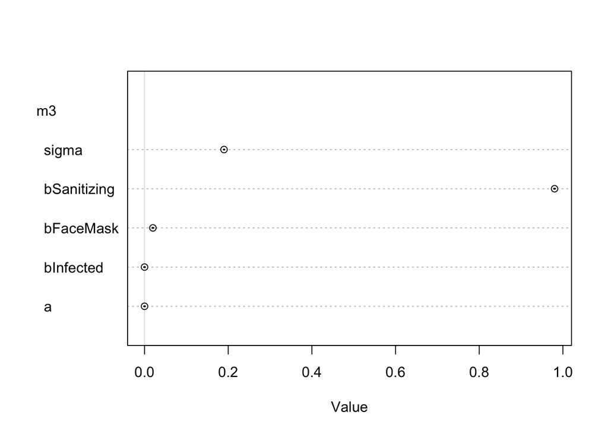

```r
m3 <- quap(
    alist(
        corona_fear_std ~ dnorm( mu , sigma ) ,
        mu <- a + bInfected * infected_std  + bFaceMask * face_mask_std + bSanitizing * sanitizing_std,
        a ~ dnorm( 0 , 0.2 ) ,
        bInfected ~ dnorm( 0 , 1 ),
        bFaceMask ~ dnorm( 0, 1 ),
        bSanitizing~ dnorm( 0 , 1 ),
        sigma ~ dexp( 1 ) # Contains no more info than an average deviation. The avg. is just the inverse of the rate, 1.
    ) , data = df )


plot(coeftab(m3),by.model=TRUE )
```

As seen in the above plot, bInfected becomes independent (i.e., the model does with almost no uncertainty estimate the coefficient bInfected to be very close to zero) when stratifying by face_mask and sanitizing.

Model 4: fc_m *||* infc_ | grm_ Testing whether the causal coefficient infc (being infected or not) significantly close to zero when stratifying by germ_level in a model that has face_mask as outcome variable.

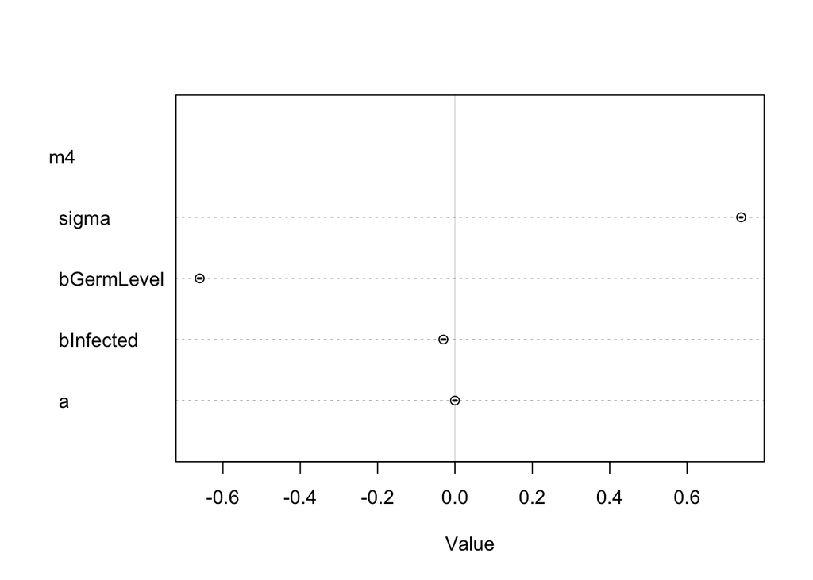

```r
m4 <- quap(
    alist(
        face_mask_std ~ dnorm( mu , sigma ) ,
        mu <- a + bInfected*infected_std  + bGermLevel*germ_std,
        a ~ dnorm( 0 , 0.2 ) ,
        bInfected ~ dnorm( 0 , 1 ) ,
        bGermLevel~ dnorm( 0 , 1 ),
        sigma ~ dexp( 1 )
    ) , data = df )

plot(coeftab(m4),by.model=TRUE)
```

Model 5: fc_m *||* sntz | crn_ Testing whether the causal coefficient of sanitizing becomes significantly close to zero when stratifying by corona fear in a model that has face_mask as outcome variable.

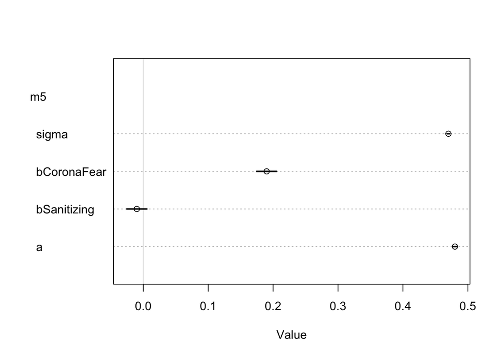

```r
m5 <- quap(
    alist(
        face_mask ~ dnorm( mu , sigma ) ,
        mu <- a + bSanitizing*sanitizing_std  + bCoronaFear*corona_fear_std,
        a ~ dnorm( 0 , 0.2 ) ,
        bSanitizing ~ dnorm( 0 , 1 ) ,
        bCoronaFear~ dnorm( 0 , 1 ),
        sigma ~ dexp( 1 )
    ) , data = df )

plot(coeftab(m5),by.model=TRUE)
```

The coefficient bSanitizing is still close to zero, but not as confidently estimated as zero as in the previous plots. OBS CHRIS: can we say that the coefficient bSanitizing is close to zero (thus in accordance with our dag), or does such as small deviation from 0 count as a violation of the implications of our DAG????

Model 6: infc_ *||* sntz | grm_ Testing whether the causal coefficient of sanitizing becomes significantly close to zero when stratifying by germ level in a model that has infected as outcome variable.

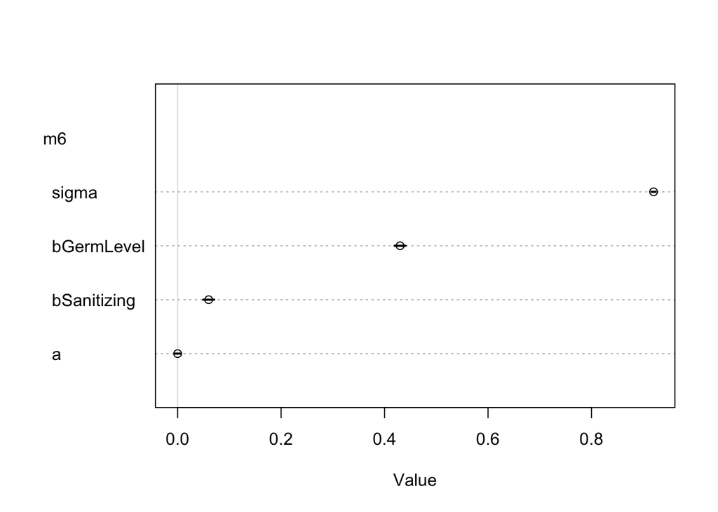

```r
m6 <- quap(
    alist(
        infected_std ~ dnorm( mu , sigma ) ,
        mu <- a + bSanitizing*sanitizing_std  + bGermLevel*germ_std,
        a ~ dnorm(0,0.2) ,
        bSanitizing ~ dnorm(0,1) ,
        bGermLevel~ dnorm(0,1),
        sigma ~ dexp(1)
    ) , data = df )

plot(coeftab(m6),by.model=TRUE)
```

Model 7: OCD *||* fc_m | crn_ Testing whether the causal coefficient of face_mask becomes significantly close to zero when stratifying by corona fear in a model that has OCD as outcome variable.

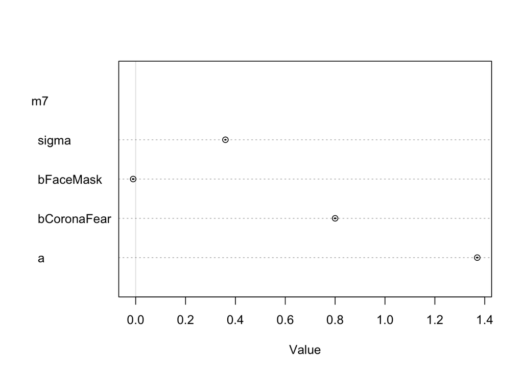

```r
m7 <- quap(
    alist(
        OCD ~ dnorm( mu , sigma ) ,
        mu <- a + bFaceMask*face_mask_std + bCoronaFear*corona_fear_std,
        a ~ dnorm( 0 , 0.2 ) ,
        bCoronaFear ~ dnorm( 0 , 0.5 ) ,
        bFaceMask ~ dnorm( 0 , 0.5 ) ,
        sigma ~ dexp( 1 ) # OBS : why exp? It doesn't change anything changing it to dnorm or dunif
    ) , data = df )

plot(coeftab(m7),by.model=TRUE)
```

As seen in the above plot, bFaceMask becomes independent from OCD (i.e., the model does with almost no uncertainty estimate the coefficient bFaceMask to be very close to zero) when stratifying by corona fear.

Model 8: OCD *||* grm_ | fc_m, sntz (OBS, not working) Testing whether the causal coefficient of germ level becomes significantly close to zero when stratifying by face mask and sanitizing in a model that has OCD as outcome variable.

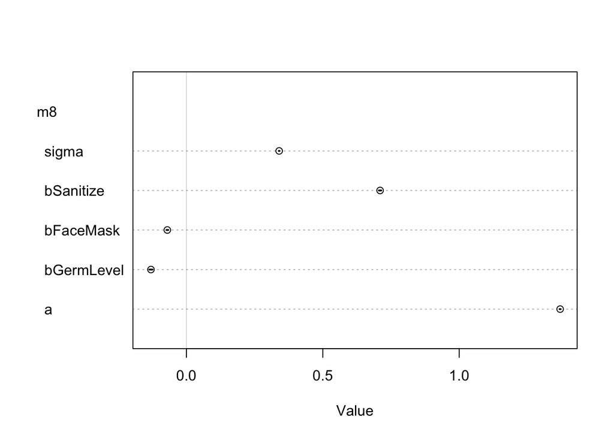

```r
m8 <- quap(
    alist(
        OCD ~ dnorm( mu , sigma ) ,
        mu <- a + bGermLevel*germ_std + bFaceMask*face_mask_std + bSanitize*sanitizing_std ,
        a ~ dnorm( 0 , 0.2 ) ,
        bGermLevel ~ dnorm( 0 , 1 ) ,
        bFaceMask ~ dnorm( 0 , 1 ) ,
        bSanitize ~ dnorm( 0 , 1 ) ,
        sigma ~ dexp( 1 ) # OBS : why exp? It doesn't change anything changing it to dnorm or dunif
    ) , data = df )

plot(coeftab(m8),by.model=TRUE)
```

```r
precis(m8)
```

|  | mean | sd | 5.5% | 94.5% |
| --- | --- | --- | --- | --- |
| a | 1.37164923 | 0.0010750075 | 1.36993116 | 1.37336729 |
| bGermLevel | -0.13446984 | 0.0029470023 | -0.13917972 | -0.12975996 |
| bFaceMask | -0.06778485 | 0.0016970557 | -0.07049707 | -0.06507263 |
| bSanitize | 0.71140516 | 0.0023440998 | 0.70765884 | 0.71515149 |
| sigma | 0.33995212 | 0.0007601352 | 0.33873728 | 0.34116696 |

(OBS) Chris: coefficient is very low - but why not almost zero? Is it the model (should we have different slopes/intercepts dependent on our categorical predictor face_mask) or does it have something to do with our data generation process???

Model 9: OCD || grm_ | crn_, sntz Testing whether the causal coefficient of germ level becomes significantly close to zero when stratifying by corona fear and sanitizing in a model that has OCD as outcome variable.

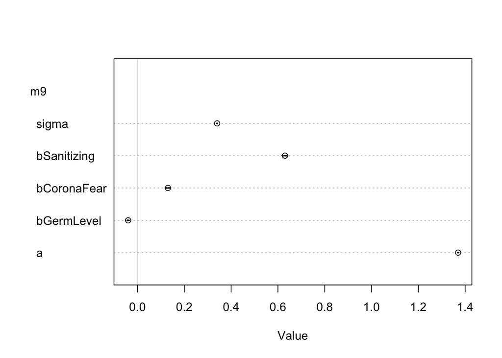

```r
m9<- quap(
    alist(
        OCD ~ dnorm( mu , sigma ) ,
        mu <- a  + bGermLevel*germ_std + bCoronaFear*corona_fear_std + bSanitizing*sanitizing_std,
        a ~ dnorm( 0 , 0.2 ) ,
        bGermLevel~ dnorm( 0 , 1 ) ,
        bCoronaFear~ dnorm( 0 , 1 ),
        bSanitizing ~ dnorm( 0 , 1 ),
        sigma ~ dexp( 1 )
    ) , data = df )

plot(coeftab(m9),by.model=TRUE)
```

As seen in the above plot, bGermLevel becomes independent from OCD (i.e., the model does with almost no uncertainty estimate the coefficient bGermLevel to be very close to zero) when stratifying by sanitizing and corona fear.

Model 10: OCD || infc | grm_ Testing whether the causal coefficient of infected becomes significantly close to zero when stratifying by germ level in a model that has OCD as outcome variable.

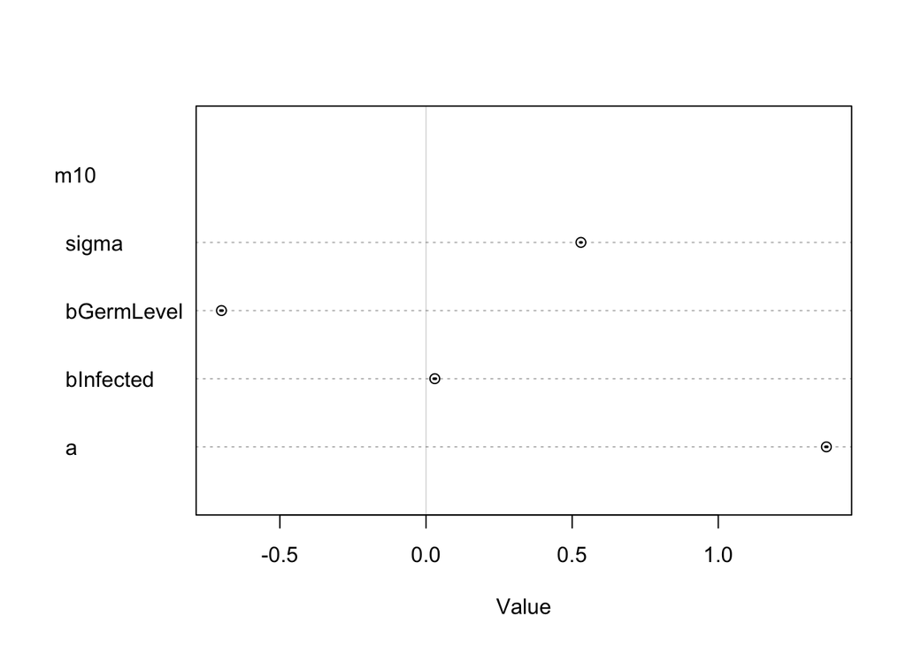

```r
m10<- quap(
    alist(
        OCD ~ dnorm( mu , sigma ) ,
        mu <- a  + bInfected*infected_std + bGermLevel*germ_std,
        a ~ dnorm( 0 , 0.2 ) ,
        bInfected ~ dnorm( 0 , 1 ),
        bGermLevel~ dnorm( 0 , 1 ) ,
        sigma ~ dexp( 1 )
    ) , data = df )

plot(coeftab(m10),by.model=TRUE)
```

As seen in the above plot, bInfected becomes independent from OCD (i.e., the model does with almost no uncertainty estimate the coefficient bInfected to be very close to zero) when stratifying by germ level.

Model 11: OCD *||* infc | fc_m, sntz Testing whether the causal coefficient of infected becomes significantly close to zero when stratifying by face mask and sanitizing in a model that has OCD as outcome variable.

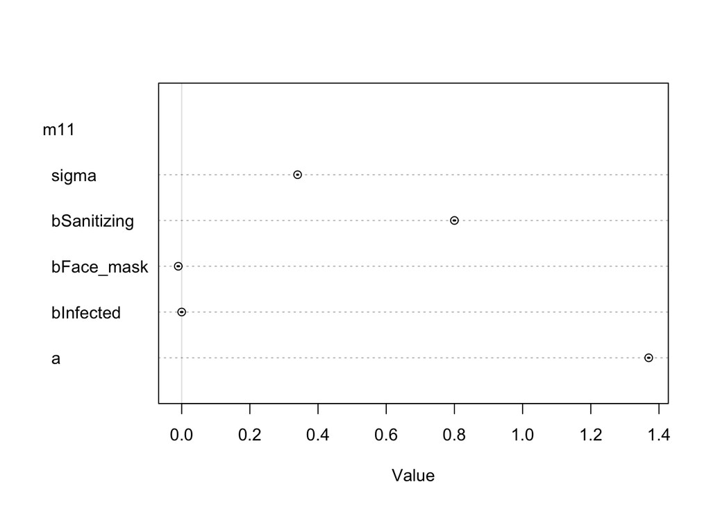

```r
m11 <-  quap(
    alist(
        OCD ~ dnorm( mu , sigma ) ,
        mu <- a + bInfected*infected_std  + bFace_mask*face_mask_std + bSanitizing*sanitizing_std,
        a ~ dnorm( 0 , 0.2 ) ,
        bInfected~ dnorm( 0 , 1 ) ,
        bFace_mask~ dnorm( 0 , 1 ),
        bSanitizing~ dnorm( 0 , 1 ),
        sigma ~ dexp( 1 )
    ) , data = df )

plot(coeftab(m11),by.model=TRUE)
```

As seen in the above plot, bInfected becomes independent from OCD (i.e., the model does with almost no uncertainty estimate the coefficient bInfected to be very close to zero) when stratifying by face mask.

Model 12: OCD *||* infc | crn_, sntz Testing whether the causal coefficient of infected becomes significantly close to zero when stratifying by corona fear and sanitizing in a model that has OCD as outcome variable.

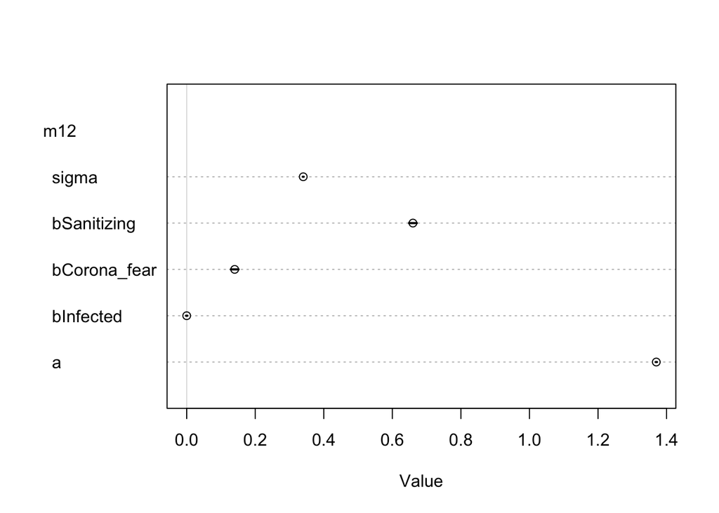

```r
m12<- quap(
    alist(
        OCD ~ dnorm( mu , sigma ) ,
        mu <- a + bInfected*infected_std  + bCorona_fear*corona_fear_std + bSanitizing*sanitizing_std,
        a ~ dnorm( 0 , 0.2 ) ,
        bInfected~ dnorm( 0 , 1 ) ,
        bCorona_fear~ dnorm( 0 , 1 ),
        bSanitizing~ dnorm( 0 , 1 ),
        sigma ~ dexp( 1 )
    ) , data = df )

plot(coeftab(m12),by.model=TRUE)
```

As seen in the above plot, bInfected becomes independent from OCD (i.e., the model does with almost no uncertainty estimate the coefficient bInfected to be very close to zero) when stratifying by sanitizing and corona fear.

## Task 4: Messing it up

- Try and **deliberately have an open back door path** and see if you can get wrong inference.

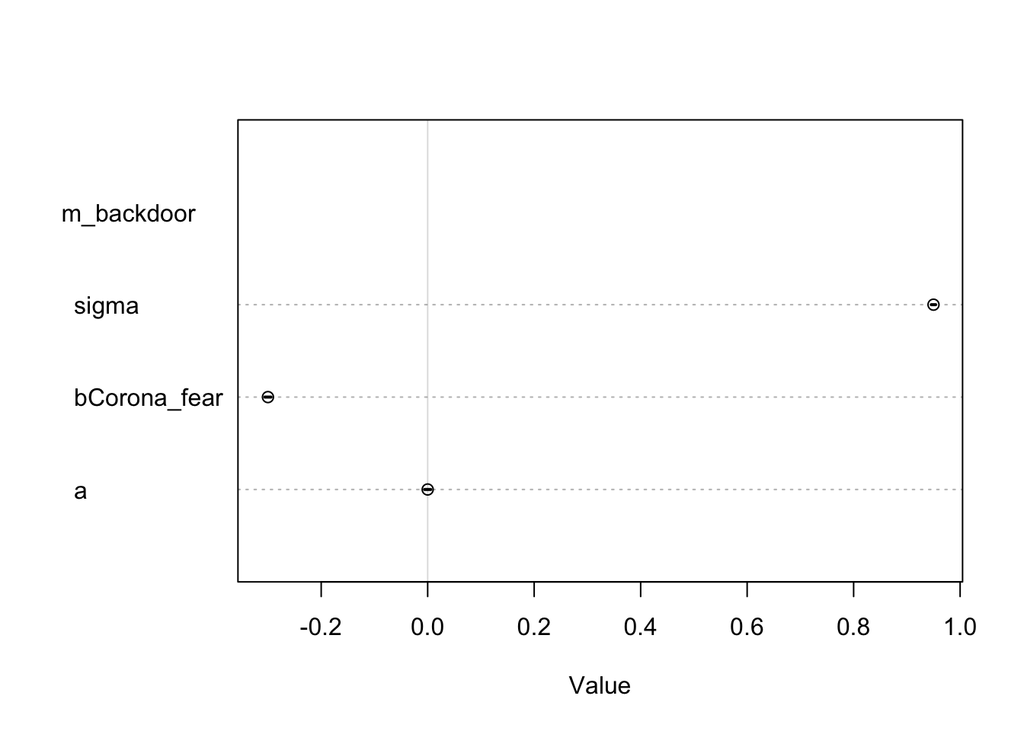

```r
m_backdoor<- quap(
    alist(
        infected_std ~ dnorm( mu , sigma ) , # (OBS ask Chris about standardizing dichotomous variable)
        mu <- a + bCorona_fear*corona_fear_std,
        a ~ dnorm( 0 , 0.2 ) ,
        bCorona_fear ~ dnorm( 0 , 1 ),
        sigma ~ dexp( 1 )
    ) , data = df )

plot(coeftab(m_backdoor),by.model=TRUE)
```

```r
m_no_backdoor<- quap(
    alist(
        infected_std ~ dnorm( mu , sigma ) , # (OBS ask Chris about standardizing dichotomous variable)
        mu <- a + bCorona_fear*corona_fear_std + bOCD*OCD,# (OBS ask Chris about standardizing dichotomous variable)
        a ~ dnorm( 0 , 0.2 ) ,
        bCorona_fear~ dnorm( 0 , 1 ),
        bOCD~ dnorm( 0 , 1 ),
        sigma ~ dexp( 1 )
    ) , data = df )

precis(m_no_backdoor)
```

|  | mean | sd | 5.5% | 94.5% |
| --- | --- | --- | --- | --- |
| a | 0.02210511 | 0.011733506 | 0.003352701 | 0.040857518 |
| bCorona_fear | -0.28661387 | 0.007208070 | -0.298133754 | -0.275093978 |
| bOCD | -0.01611970 | 0.008268362 | -0.029334136 | -0.002905256 |
| sigma | 0.95410653 | 0.002133421 | 0.950696909 | 0.957516147 |

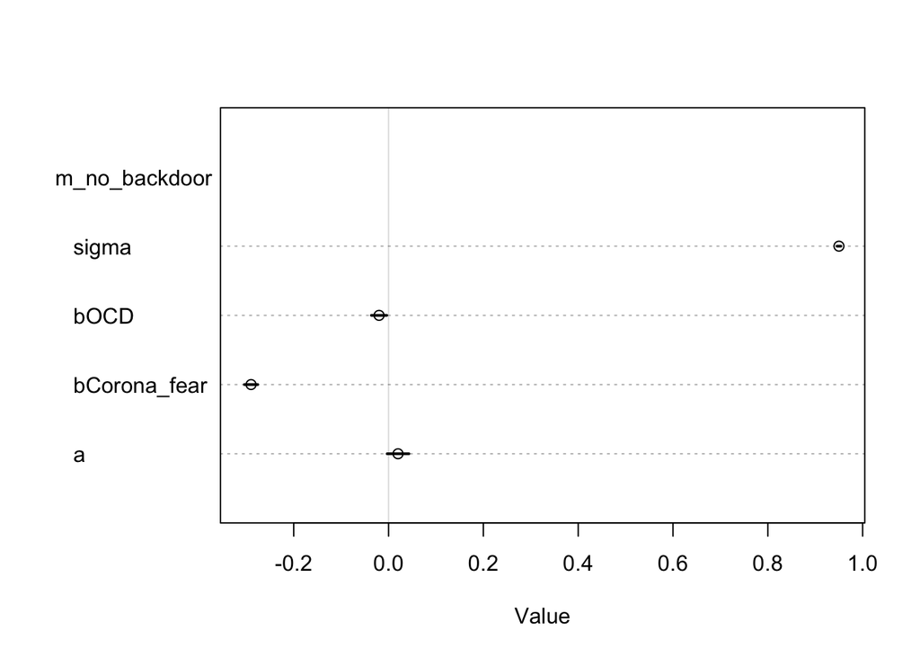

```r
plot(coeftab(m_no_backdoor),by.model=TRUE)
```

```r
precis(m_backdoor)
```

|  | mean | sd | 5.5% | 94.5% |
| --- | --- | --- | --- | --- |
| a | -1.009885e-07 | 0.003016853 | -0.004821615 | 0.004821413 |
| bCorona_fear | -2.993776e-01 | 0.003017198 | -0.304199669 | -0.294555540 |
| sigma | 9.541212e-01 | 0.002133442 | 0.950711589 | 0.957530895 |

```r
precis(m_no_backdoor)
```

|  | mean | sd | 5.5% | 94.5% |
| --- | --- | --- | --- | --- |
| a | 0.02210511 | 0.011733506 | 0.003352701 | 0.040857518 |
| bCorona_fear | -0.28661387 | 0.007208070 | -0.298133754 | -0.275093978 |
| bOCD | -0.01611970 | 0.008268362 | -0.029334136 | -0.002905256 |
| sigma | 0.95410653 | 0.002133421 | 0.950696909 | 0.957516147 |

- Try and deliberately **simulate some data that doesn’t fit the DAG**, or **create a new DAG that doesn’t fit the data**.

*We will now simulate some sata that does not fit the DAG*

```r
# Corona fear (assuming that it is normally distributed)
corona_fear_w <-rnorm(N, mean=50, sd=10)

# Face mask (depending on germ level)
face_mask_w <- rbinom(N, size =1, prob= inv_logit(scale(germ_level)))

# Sanitizing (depending on germ_level)
sanitizing_w <- rnorm(N, mean= germ_level-20, sd=2)

# Germ level (depending on corona fear and face mask)
germ_level_w <-  rnorm(N, mean= 5000 - ((corona_fear*10)*(1+face_mask)), sd=100)

# Infected (not depending on any of the variables)
infected_w <-  rbinom(N, size= 1, prob=0.2)


# OCD level
OCD_w <- sample(1:5, size=N, replace=TRUE, prob=c(.8, .10, .05, .03, .02)) # 80% of not having OCD, apx. 2% chance for severe OCD

# creating df
df_w <- tibble(germ_level_w, sanitizing_w, infected_w, face_mask_w, corona_fear_w, OCD_w)
```